# Getting Data from SEC’s EDGAR

Matthias Uckert

19 April, 2021

# Description

In this section we will retrieve information from the SEC EDGAR database. Getting data from EDGAR is exemplary for getting information from the web, where we have API (Application Programming Interface) access.

# Script Setup

```r
library(tidyverse); library(edgarWebR); library(lubridate); library(here)
library(furrr); library(stringi); library(textstem); library(tidytext)
library(janitor); library(tools); library(patchwork); library(scales)
library(summarytools); library(kableExtra)

source("1_code/00_functions/f-all.R")
source("1_code/00_functions/f-get_edgar_data.R")
```

# Code

## Paths

```r
lst_paths <- list(
  dir_main    = "2_output/01_get_edgar_data/",
  path_filing = "2_output/01_get_edgar_data/edgar_filings.rds",
  path_detail = "2_output/01_get_edgar_data/edgar_details.rds"
) %>% create_dirs()
```

## Get Fortune 500 Companies

Her we use an open source data repository ‘datahub.io’ to retrieve the **fortune 500 companies** with some financial information. We won’t use the complete data set, but filter for the top 100 companies (using less companies will let the code run faster) with the highest market capitalization. You can change the number of companies by changing the integer vector: **.n_companies** in the chunk below.

Throughout this script we will use custom functions to download and transform data. All the script specific functions are stored in this folder: **1_code/00_functions/f-get_edgar_data.R**

**Note:** Look at the function **get_f500()**

```r
.n_companies <- 100
```

```r
# View(get_f500)
```

| symbol | name | sector |
| --- | --- | --- |
| AAPL | Apple Inc. | Information Technology |
| GOOGL | Alphabet Inc Class A | Information Technology |
| GOOG | Alphabet Inc Class C | Information Technology |
| MSFT | Microsoft Corp. | Information Technology |
| AMZN | Amazon.com Inc | Consumer Discretionary |
| FB | Facebook, Inc. | Information Technology |
| JPM | JPMorgan Chase & Co. | Financials |
| JNJ | Johnson & Johnson | Health Care |
| XOM | Exxon Mobil Corp. | Energy |
| BAC | Bank of America Corp | Financials |

## Get Company Index-Links

We use a custom function: **map_company_filings()** to retrieve the Index Links from EDGAR.

```r
# View(map_company_filings)
```

Here we use a really simple caching procedure so that we don’t have to re-run the whole expression if we already extracted index-links.

```r
if (!file.exists(lst_paths$path_filing)) {
  .prc <- tibble(symbol = character(), .rows = 0)
} else {
  .prc <- read_rds(lst_paths$path_filing)
}

tab_f500_use <- filter(tab_f500_t10, !symbol %in% .prc$symbol)

if (nrow(tab_f500_use) > 0) {
  lst_filings <- map_company_filings(
    .tickers = tab_f500_use$symbol, .type = "10-K", .count = 100, .sleep = .2
    )
  tab_filings <- bind_rows(.prc, bind_rows(lst_filings$result, .id = "symbol"))
  write_rds(tab_filings, lst_paths$path_filing)
} else {
  tab_filings <- .prc
}
```

```
[=========================================>----------------------------------------------------------------------------------------------------------------------------]  25%
[=============================================================>--------------------------------------------------------------------------------------------------------]  38%
[==================================================================================>-----------------------------------------------------------------------------------]  50%
[=======================================================================================================>--------------------------------------------------------------]  62%
[===========================================================================================================================>------------------------------------------]  75%
[================================================================================================================================================>---------------------]  88%
[======================================================================================================================================================================] 100%
```

```
[1] "Results: 0"
[1] "Errors:  8"
```

```r
tab_filings <- tab_filings %>%
  mutate(id = stri_replace_all_fixed(
    basename(href), paste0(".", file_ext(href)), "")
    ) %>% distinct(id, .keep_all = TRUE)
```

In total we got 8 errors.

```r
tab_f500_t10 %>%
  filter(!symbol %in% read_rds(lst_paths$path_filing)$symbol) %>%
  show_table(.n = 5)
```

| symbol | name | sector | price | price_earnings | dividend_yield | earnings_share | x52_week_low | x52_week_high | market_cap | ebitda | price_sales | price_book | sec_filings |
| --- | --- | --- | --- | --- | --- | --- | --- | --- | --- | --- | --- | --- | --- |
| BRK.B | Berkshire Hathaway | Financials | 191.42 | 30.43 | 0.000000 | 9.76 | 217.62 | 160.93 | 261401203633 | 0 | 1.432823 | 1.58 | http://www.sec.gov/cgi-bin/browse-edgar?action=getcompany&CIK=BRK.B |
| DWDP | DowDuPont | Materials | 68.21 | 49.43 | 2.152975 | 1.59 | 77.08 | 64.01 | 165203312427 | 5250000000 | 2.692239 | 1.54 | http://www.sec.gov/cgi-bin/browse-edgar?action=getcompany&CIK=DWDP |
| UTX | United Technologies | Industrials | 127.48 | 19.26 | 2.121694 | 5.70 | 139.24 | 107.05 | 105387272474 | 10584000000 | 1.732412 | 3.40 | http://www.sec.gov/cgi-bin/browse-edgar?action=getcompany&CIK=UTX |
| PCLN | Priceline.com Inc | Consumer Discretionary | 1806.06 | 24.26 | 0.000000 | 42.66 | 2067.99 | 1589.00 | 91817448863 | 4803487000 | 9.176564 | 6.92 | http://www.sec.gov/cgi-bin/browse-edgar?action=getcompany&CIK=PCLN |
| CELG | Celgene Corp. | Health Care | 91.02 | 13.27 | 0.000000 | 3.58 | 147.17 | 92.85 | 74921079154 | 5233000000 | 5.830071 | 7.49 | http://www.sec.gov/cgi-bin/browse-edgar?action=getcompany&CIK=CELG |

```r
# browseURL("https://www.sec.gov/cgi-bin/browse-edgar?company=BRK.B&match=&filenum=&State=&Country=&SIC=&myowner=exclude&action=getcompany")
```

Let’s quickly look at the result. (There are several ways to do this. For small Dataframes we can simply use the RStudio build-in viewer)

```r
show_table(tab_filings, .n = 5)
```

| symbol | accession_number | act | file_number | filing_date | accepted_date | href | type | film_number | form_name | description | size | id |
| --- | --- | --- | --- | --- | --- | --- | --- | --- | --- | --- | --- | --- |
| AAPL | NA | 34 | 001-36743 | 2020-10-30 | 2020-10-29 | https://www.sec.gov/Archives/edgar/data/320193/000032019320000096/0000320193-20-000096-index.htm | 10-K | 201273977 | Annual report [Section 13 and 15(d), not S-K Item 405] | NA | 12 MB | 0000320193-20-000096-index |
| AAPL | NA | 34 | 001-36743 | 2019-10-31 | 2019-10-30 | https://www.sec.gov/Archives/edgar/data/320193/000032019319000119/0000320193-19-000119-index.htm | 10-K | 191181423 | Annual report [Section 13 and 15(d), not S-K Item 405] | NA | 12 MB | 0000320193-19-000119-index |
| AAPL | NA | 34 | 001-36743 | 2018-11-05 | 2018-11-05 | https://www.sec.gov/Archives/edgar/data/320193/000032019318000145/0000320193-18-000145-index.htm | 10-K | 181158788 | Annual report [Section 13 and 15(d), not S-K Item 405] | NA | 12 MB | 0000320193-18-000145-index |
| AAPL | NA | 34 | 001-36743 | 2017-11-03 | 2017-11-03 | https://www.sec.gov/Archives/edgar/data/320193/000032019317000070/0000320193-17-000070-index.htm | 10-K | 171174673 | Annual report [Section 13 and 15(d), not S-K Item 405] | NA | 14 MB | 0000320193-17-000070-index |
| AAPL | NA | 34 | 001-36743 | 2016-10-26 | 2016-10-26 | https://www.sec.gov/Archives/edgar/data/320193/000162828016020309/0001628280-16-020309-index.htm | 10-K | 161953070 | Annual report [Section 13 and 15(d), not S-K Item 405] | NA | 13 MB | 0001628280-16-020309-index |

## Get Company Details

After we got the index links from EDGAR, we proceed by scraping filing details. Again, we use a custom function to do this **map_filing_details()** and use a simple caching algorithm.

```r
if (!file.exists(lst_paths$path_detail)) {
  .prc <- tibble(id = character(), .rows = 0)
} else {
  .prc <- read_rds(lst_paths$path_detail)
}
tab_filings_use <- filter(tab_filings, !id %in% .prc$id)

if (nrow(tab_filings_use) > 0) {
  lst_details <- map_filing_details(
    .id = tab_filings_use$id, .hrefs = tab_filings_use$href, .sleep = 1
    )
  lst_details <- transpose(lst_details$result)
  lst_details <- map(lst_details, ~ bind_rows(.x, .id = "id"))
  tab_details <- reduce(lst_details, left_join, by = "id")

  tab_details <- bind_rows(.prc, .tab_details)
  write_rds(.tab_details, lst_paths$path_detail)
} else {
  tab_details <- .prc
}
rm(tab_filings_use)
```

From the **2,364** index links we retrieved in the last step, we got **89,302** different document links.

It’s important to notice, that such data retrieval tasks often result in very large datasets.

```r
# View(tab_details)
tab_details %>%
  mutate(year = year(period_date)) %>%
  rename(type = type.x) %>%
  group_by(type, year) %>%
  count() %>%
  pivot_wider(names_from = year, values_from = n, names_sort = TRUE, values_fill = 0) %>%
  show_table()
```

| type | 1993 | 1994 | 1995 | 1996 | 1997 | 1998 | 1999 | 2000 | 2001 | 2002 | 2003 | 2004 | 2005 | 2006 | 2007 | 2008 | 2009 | 2010 | 2011 | 2012 | 2013 | 2014 | 2015 | 2016 | 2017 | 2018 | 2019 | 2020 | 2021 |
| --- | --- | --- | --- | --- | --- | --- | --- | --- | --- | --- | --- | --- | --- | --- | --- | --- | --- | --- | --- | --- | --- | --- | --- | --- | --- | --- | --- | --- | --- |
| 10-K | 780 | 855 | 900 | 938 | 929 | 1020 | 1056 | 1058 | 875 | 2258 | 2629 | 2666 | 2843 | 3037 | 2932 | 3400 | 3855 | 3965 | 4116 | 4117 | 4124 | 4008 | 4863 | 4744 | 4626 | 4586 | 4830 | 4868 | 280 |
| 10-K/A | 124 | 185 | 142 | 106 | 74 | 111 | 92 | 80 | 147 | 232 | 170 | 150 | 140 | 126 | 248 | 174 | 75 | 141 | 44 | 148 | 30 | 53 | 76 | 36 | 116 | 47 | 44 | 36 | 0 |
| 10-K405 | 0 | 347 | 469 | 491 | 696 | 464 | 572 | 611 | 812 | 0 | 0 | 0 | 0 | 0 | 0 | 0 | 0 | 0 | 0 | 0 | 0 | 0 | 0 | 0 | 0 | 0 | 0 | 0 | 0 |
| 10-K405/A | 0 | 28 | 28 | 109 | 149 | 72 | 42 | 97 | 10 | 0 | 0 | 0 | 0 | 0 | 0 | 0 | 0 | 0 | 0 | 0 | 0 | 0 | 0 | 0 | 0 | 0 | 0 | 0 | 0 |

## Select Documents for Download

In order to reduce the amount of documents we download, we pre-select specific documents.

```r
tab_download <- tab_details %>%
  distinct() %>%
  left_join(select(tab_filings, symbol, id), by = "id") %>%
  mutate(
    file_ext = tools::file_ext(href),
    year = year(period_date),
    size = size / 1e6,
    across(where(is.character), ~ stri_replace_all_regex(., "[[:blank:]]+", " ")),
    across(c(type.y, description.y), ~ if_else(. %in% c("", " "), NA_character_, .))
    ) %>%
  select(id, document, state = company_incorporation_state,
         sic = sic_code, year, symbol, company_name, company_cik,
         type1 = type.x, type2 = type.y, desc = description.y,
         period_date, href, size, file_ext) %>%
  filter(between(year, 2005, 2020))
```

```r
tab_download %>%
  rename(type = type1) %>%
  group_by(type, year) %>%
  count() %>%
  pivot_wider(names_from = year, values_from = n, names_sort = TRUE, values_fill = 0) %>%
  show_table()
```

| type | 2005 | 2006 | 2007 | 2008 | 2009 | 2010 | 2011 | 2012 | 2013 | 2014 | 2015 | 2016 | 2017 | 2018 | 2019 | 2020 |
| --- | --- | --- | --- | --- | --- | --- | --- | --- | --- | --- | --- | --- | --- | --- | --- | --- |
| 10-K | 1357 | 1455 | 1401 | 1629 | 1844 | 1896 | 1969 | 1950 | 1970 | 1907 | 2326 | 2268 | 2200 | 2193 | 2308 | 2337 |
| 10-K/A | 62 | 63 | 124 | 87 | 31 | 58 | 22 | 74 | 15 | 24 | 28 | 18 | 58 | 22 | 22 | 18 |

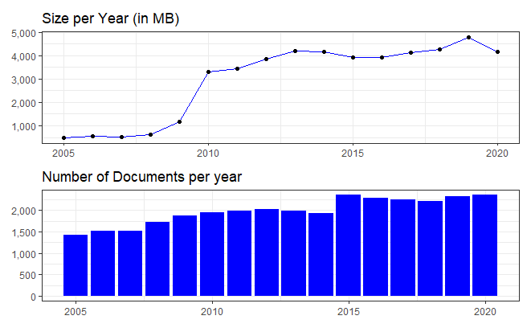

```r
.tmp <- tab_download %>%
  group_by(year) %>%
  summarise(size = sum(size), n = n(), .groups = "drop")


.geom_size <- .tmp %>%
  ggplot(aes(x = year, y = size)) +
  geom_line(color = "blue") +
  geom_point() +
  labs(x = NULL, y = NULL) +
  scale_y_continuous(labels = scales::comma) +
  theme_bw() +
  ggtitle("Size per Year (in MB)")

.geom_n <- .tmp %>%
  ggplot(aes(x = year, y = n)) +
  geom_col(fill = "blue") +
  labs(x = NULL, y = NULL) +
  scale_y_continuous(labels = scales::comma) +
  theme_bw() +
  ggtitle("Number of Documents per year")

.geom_size / .geom_n
```

```r
NA
```

```r
tab_download_txt <- tab_download %>%
  filter(file_ext == "txt", desc == "Complete submission text file") %>%
  arrange(symbol, desc(year), desc(period_date)) %>%
  distinct(symbol, year, .keep_all = TRUE) %>%
  distinct(document, .keep_all = TRUE)

cat(paste0(
  "Docs: ", comma(nrow(tab_download_txt)), "\n",
  "Size: ", comma(sum(tab_download_txt$size)), " MB")
  )
```

```
Docs: 1,327
Size: 28,347 MB
```

```r
tab_download_htm <- tab_download %>%
  filter(startsWith(file_ext, "htm"), grepl("10-K", desc)) %>%
  arrange(symbol, desc(year), desc(period_date)) %>%
  distinct(symbol, year, .keep_all = TRUE) %>%
  distinct(document, .keep_all = TRUE)

cat(paste0(
  "Docs: ", comma(nrow(tab_download_htm)), "\n",
  "Size: ", comma(sum(tab_download_htm$size)), " MB")
  )
```

```
Docs: 967
Size: 3,728 MB
```

```r
tab_download_xxx <- tab_download %>%
  filter(startsWith(file_ext, "x")) %>%
  arrange(symbol, desc(year), desc(period_date)) %>%
  distinct(document, .keep_all = TRUE)

cat(paste0(
  "Docs: ", comma(nrow(tab_download_xxx)), "\n",
  "Size: ", comma(sum(tab_download_xxx$size)), " MB")
  )
```

```
Docs: 6,049
Size: 9,511 MB
```

## Download Documents

Again we use a custom function **download_edgar_files()** to download the documents.

```r
.dir_docs <- "2_output/01_get_edgar_data/documents/"
tab_xxx <- download_edgar_files(tab_download_xxx, .dir_docs, 10, 2)
tab_htm <- download_edgar_files(tab_download_htm, .dir_docs, 10, 2)
tab_txt <- download_edgar_files(tab_download_txt, .dir_docs, 10, 2)

tab_zip_files <- list_files_tab(.dir_docs, info = TRUE) %>%
  select(doc_id, file_ext, path, size) %>%
  mutate(size = size / 1e6)
```

```r
cat(paste0(
  "Docs: ", comma(nrow(tab_zip_files)), "\n",
  "Size: ", comma(sum(tab_zip_files$size)), " MB")
  )
```

```
Docs: 3,298
Size: 3,768 MB
```

## Save Files

```r
write_rds(tab_download_htm, "2_output/01_get_edgar_data/htm_download.rds")
write_rds(tab_download_txt, "2_output/01_get_edgar_data/txt_download.rds")
write_rds(tab_download_xxx, "2_output/01_get_edgar_data/xxx_download.rds")
```

# Own Function Calls

```r
lsf.str()
```

```
create_dirs : function (.dirs)
display_top_n_by : function (.tab, .col)
download_edgar_files : function (.tab, .dir, .retry = 5, .sleep = 1)
download_google_drive : function (.id, .dir = NULL, .read_fun = NULL, .overwrite = FALSE)
get_f500 : function ()
get_lm_stop : function ()
get_ngrams : function (.path, .ngram, .stop = tibble(word = "", .rows = 0), .rm_num = TRUE)
list_files_tab : function (dirs, reg = "*", id = "doc_id", rec = FALSE, info = FALSE)
map_company_filings : function (.tickers, .ownership = FALSE, .type = "", .before = "", .count = 100, .page = 1, .progress = TRUE, .sleep = 0, .retry = 5)
map_filing_details : function (.id, .hrefs, .progress = TRUE, .sleep = 0, .retry = 5)
pdf_read_and_tokenize : function (.path, .dir)
prep_top_n_by : function (.tab_word, .tab_data, .col, .n = 10)
remove_html_tags : function (.string, rm_linebreaks = TRUE)
sec_read_and_tokenize : function (.path, .dir = NULL)
show_table : function (.tab, .n = Inf)
```

|  | setting | value |
| --- | --- | --- |
| version | version | R version 4.0.3 (2020-10-10) |
| os | os | Windows 10 x64 |
| system | system | x86_64, mingw32 |
| ui | ui | RStudio |
| language | language | (EN) |
| collate | collate | English_Germany.1252 |
| ctype | ctype | English_Germany.1252 |
| tz | tz | Europe/Berlin |
| date | date | 2021-04-19 |